# Integração Monte Carlo

Prof. Lupercio F. Bessegato

27/07/2021

### Introdução

As duas maiores classes de problemas numéricos em inferência estatística relacionam-se com otimização e integração. Em geral, os problemas associados com a solução de equações implícitas podem ser reformulados como un problema de otimização. Embora não haja classificações estritas dessas classes de problemas, os problemas de otimização estão geralemnte associados com a abordagem de verossimilhança e, os de integração, com a abordagem bayesiana.

Entretanto, nem sempre é possível calcular analiticamente os estimadores associados a um dado problema (máxima verossimilhança, método dos momentos, etc.). Assim, seja qual for o tipo de inferência estatística, freqüentemente é necessário considerar soluções numéricas. Uma solução geral é usar a simulação da distribuição verdadeira ou de alguma distribuição substituta para calcular as quantidades de interesse. A possibilidade de produzir um número quase infinito de variáveis aleatórias distribuídas de acordo com uma dada distribuição, dá acesso ao uso de resultados frequentistas e assintóticos muito mais facilmente do que nos cenários inferenciais usuais. Pode-se assim aplicar resultados probabilísticos como a Lei dos Grandes Números ou o Teorema do Limite Central, uma vez que é possível avaliar a convergência dos métodos de simulação (a qual é equivalente aos limites determinísticos usados pelas abordagens numéricas).

Os métodos numéricos, como o de Simpson e as quadraturas gaussianas, são uma alternativa óbvia ao uso de métodos de simulação para aproximar integrais da forma $\int_ {R_X} h (x) f(x) \operatorname{d}\! x$, em que `f` é uma função de densidade de probabilidade. O R oferece duas funções que executam integração simples, `area()` (pacote `MASS`) e `integrate()`. No entanto, a função `area()` não trabalhar com limites infinitos na integral, exigindo, portanto, um conhecimento prévio da região de integração. Por outro lado, a função `integrate()` aceita limites infinitos, mas infelizmente não é robusta e pode produzir saídas sem confiabilidade.

#### Exemplo

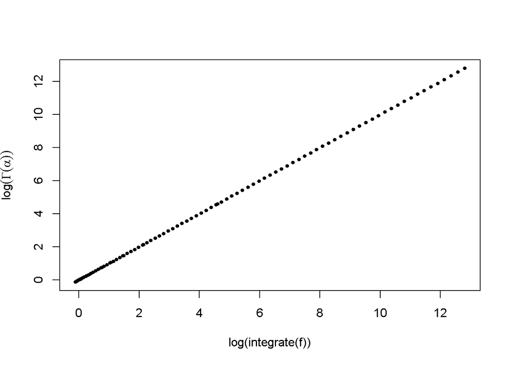

```r
  # integração numérica da função gama - integrate()
f.gama <- function(a){integrate(function(x){x^(a - 1)*exp(-x)},0,Inf)$val}

  # valores do parâmetro alfa da função gama
alfa <- seq(0.01, 10, le = 100)

  # gráfico do log da função gama - log(integrate()) vs. lgamma()
plot(lgamma(alfa), log(sapply(alfa, f.gama)),
    xlab = "log(integrate(f))", ylab = expression(log(Gamma(alpha))),
    pch = 19, cex = 0.6)
```

Não se percebe diferenças nas quantidades aproximadas por `integrate()`, mesmo para pequenos valores de $\alpha$ (todos os pontos situam-se praticamente sobre a identidade).

A principal dificuldade dos métodos de integração numérica, como `integrate()`, é que muitas vezes eles não conseguem identificar as regiões de importantes para a integração dafunção. Por outro lado, os métodos de simulação focam estas regiões naturalmente, ao explorar as informações fornecidas pela função de densidade de probabilidade associada às integrais.

#### Exemplo

Considere uma amostra $x_1, x_2, \dots, x_n$, de variáveis aleatórias independentes e com distribuição de Cauchy, com parâmtero de locação $\theta = 350$. Deseja-se obter a quantidade

$$m(\mathbf{x}) = \int_{-\infty}^\infty \prod_{i=1}^{10} \frac{1}{\pi}
\frac{1}{1 + (x_i - \theta)^2} \operatorname{d}\! \theta.$$

```r
  # amostra Cauchy
amostra <- rcauchy(10)+350

  # função de verossimilhança
veros <- function(teta){
        u <- dcauchy(amostra[1]- teta)
        for (i in 2:10)
            u <- u*dcauchy(amostra[i]- teta)
            return(u)
}

  # integral em toda a reta
integrate(veros,-Inf,Inf)
```

```
## 5.899823e-44 with absolute error < 1.2e-43
```

```r
  # integral região da cauda superior
integrate(veros, 200, 400)
```

```
## 3.729636e-11 with absolute error < 6.9e-11
```

A função `integrate()` fornece valor errado, falhando em sinalizar a dificuldade de aproximar o valor exato, já que o erro de aproximação é muito pequeno. O resultado obtido pela função `area()` é muito melhor

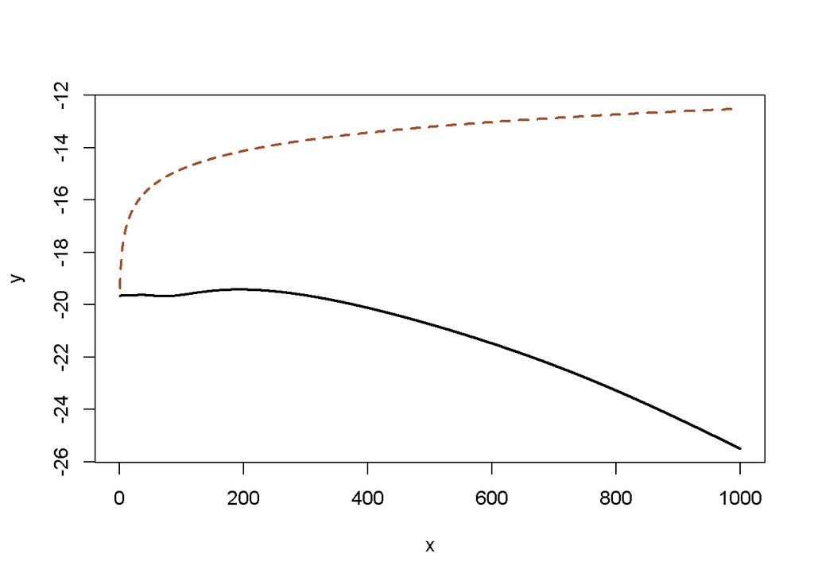

```r
        # -----  Comparação integrate() e area()

  # amostra - locação zero
amostra <- rcauchy(10)

  # integração em região simétrica - integrate()
nin <- function(a){integrate(veros, -a, a)$val}

  # integração em região simétrica - area()
nan <- function(a){MASS::area(veros,-a, a)}

 # limites de integração
x <- seq(1, 1E3, le = 1E4)
  # integrais por integrate()
y <- log(apply(as.matrix(x),1,nin))
  # integrais por area()
z <- log(apply(as.matrix(x),1,nan))

  # comparação entre integrate() e area() - logescala
plot(x, y, type = "l", ylim = range(cbind(y,z)), lwd = 2)
lines(x, z, lty=2, col = "sienna", lwd = 2)
```

Na figura acima, observa-se a comparação entre `integrate()` e `area()` na aproximação da integral de $m(\mathbf{x})$, em escala logarítmica. (a curva tracejada corresponde ao resultado obtido com a função `area()`). Percebe-se, nesse caso, que o uso de `area()` oferece uma avaliação mais confiável, já que a `area(veros, -a, a)` aumenta à medida com o aumento de `a`. Isso obviamente exige algum conhecimento prévio sobre a localização da moda do integrando. Observe abaixo o gráfico do integrando e perceba as situações relacionadas com as aproximações obtidas anteriormente.

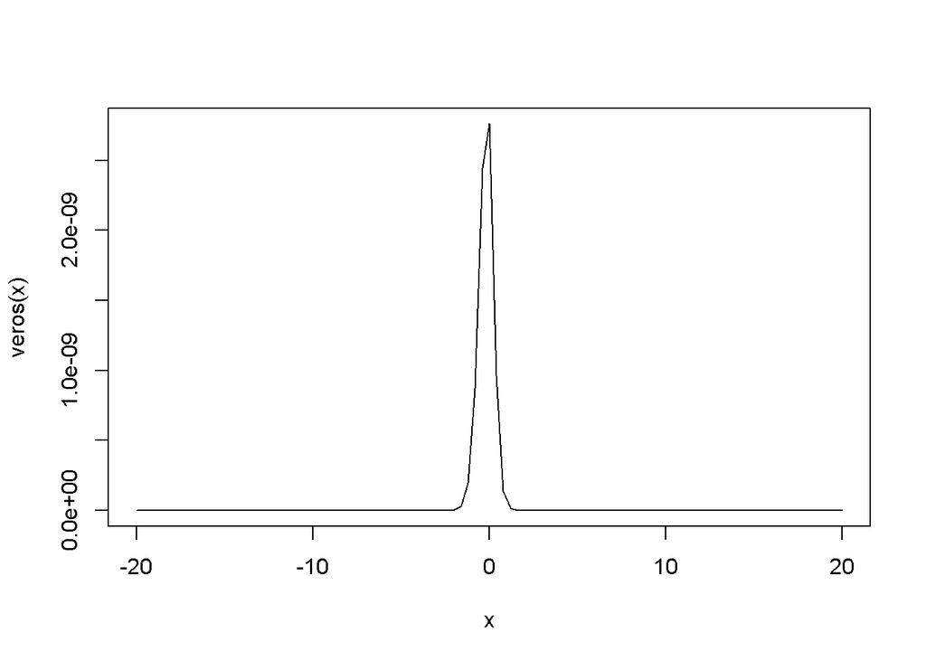

```r
 # plot do integrando
curve(veros, from = -0.2E2, to = 0.2E2)
```

Por último, os procedimentos de integração numérica não resolvem facilmente as integrais multidimensionais (com quantidade moderada ou alta de variáveis), as quais são a regra em problemas estatísticos. O desenvolvimento de ferramentas de integração específicas para esses problemas seria muito caro computacionalmente, até porque podemos tirar proveito da natureza probabilística dessas integrais.

### Eficiência na Programação em R:

É importante usar as funções em R de maneira completa. Por exemplo, desejamos usar simulação Monte Carlo para estimar a integral:

$$\int_0^1 x^2 \operatorname{d}\! x.$$

Basicamente, seria como se atirássemos em direção à região do plano que contém a curva e contássemos a quantidade de acertos abaixo da curva. Observe o gráfico abaixo:

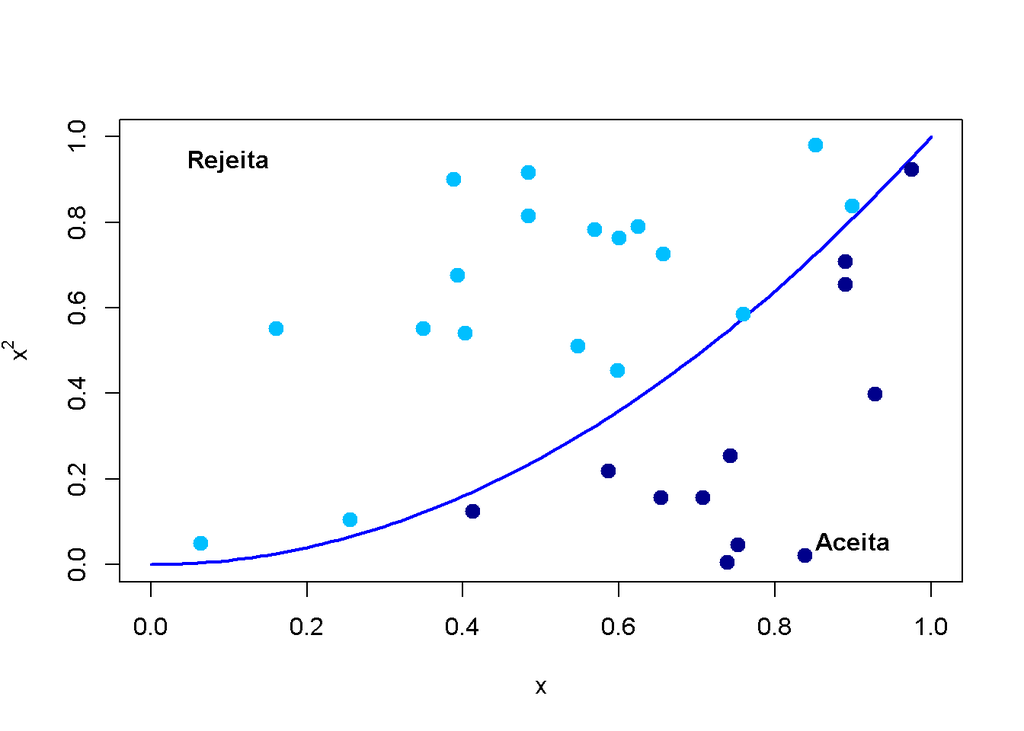

```r
    # Exemplo de simulação Monte Carlo para estimar área

  # função a ser integrada no intervalo (0, 1)
curve(x^2, from = 0, to = 1, lwd = 2, col = "blue", ylab = expression(x^2))

  # geração dos pontos a serem plotados
pontos <- 30
u1 <- runif(30)
u2 <- runif(30)

  # aceitação/rejeição dos pontos
aceita <- u1^2 > u2

  # aceita = T; rejeita = F
codigos <- as.factor(aceita)

  # cores dos pontos conforme região
cores <- c("deepskyblue", "darkblue")

  # anotação dos pontos gerados
points(u1, u2, col = cores[codigos], pch = 19, cex = 1.3)
  # identificação das regiões
text(0.9, 0, pos = 3, font = 2, label = "Aceita")
text(0.1, 1, pos = 1, font = 2, label = "Rejeita")
```

Para estimar a área abaixo da curva são plotados no gráfico pontos aleatórios, contando-se a quantidade de pontos que estão abaixo da curva.

Um algoritmo clássico para efetuar esse tipo de estimativa seria:

```
1. Inicialização: rodadas = 0
2. for i in 1:n`
3.    Gerar U1 e U2. dois números ao acaso entre 0 e 1.
4.    Se U2 < U1^2, então rodadas = rodadas +1
5. Final do for.
6. Área estimada: rodadas/N
```

O seguinte código seria uma possível implementação para esse algoritmo de simulação Monte Carlo:

```r
  # função não vetorizada
MonteCarlo <- function(N) {
  rodadas = 0
  for (i in seq_len(N)) {
    U1 <- runif(1)
    U2 <- runif(1)
    if (U1^2 > U2)
      rodadas = rodadas + 1
  }
  return(rodadas / N)
}
```

A função criada pelo código acima não é vetorizada e verifica-se seu tempo de execução.

```r
  # tempo de execução
N <- 5E5
system.time(MonteCarlo(N))
```

```
##    user  system elapsed
##    2.51    0.00    3.12
```

Uma abordagem mais voltada ao R seria:

```r
  # função vetorizada
MonteCarlo.vet <- function(N) sum(runif(N)^2 > runif(N)) / N
```

A função `MonteCarlo.vet()` contém pelo menos quatro aspectos de vetorização:

- A função `runif()` é integralmente vetorizada.
- Elevamos vetores inteiros ao quadrado com o operador `^`.
- As comparações com o operador `>` são vetorizadas.
- A função `sum()` é mais rápida que seu equivalente em um loop

```r
  # tempo de execução
N <- 5E5
system.time(MonteCarlo.vet(N))
```

```
##    user  system elapsed
##    0.04    0.00    0.05
```

Uma outra questão é sobre a precisão da estimativa. Uma pergunta pertinente é se a aproximação da integral fica mais precisa se forem usados mais pontos aleatórios.

#### Exemplo

vamos obter uma estimativa Monte Carlo para a integral:

$$\int_0^1 sen(10x^2)^2sen(x) + 0.1 \operatorname{d}\! x$$

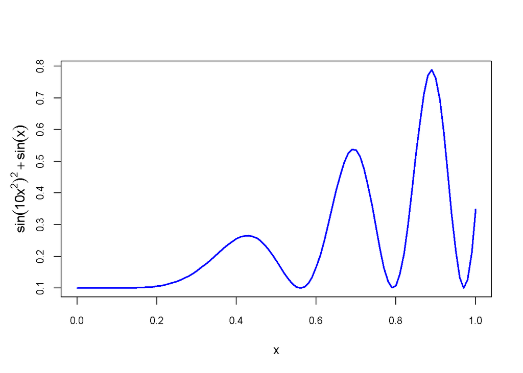

```r
  # função do integrando
f <- function(x) ((sin(10*x^2))^2*sin(x))*x + 0.1

  # gráfico da função
curve(f, from = 0, to = 1, lwd = 2, col = "blue", ylab = "", cex.axis = 0.8)
title(ylab = expression(sin(10*x^2)^2+sin(x)), line = 2, cex.lab = 1.1)
```

```r
  # área abaixo da curva - exata
(int.ex <- integrate (f, lower = 0, upper = 1)$value)
```

```
## [1] 0.2426328
```

Embora a integral possa ser calculada analiticamente, a função integrate() fornece o valor de 0.2426328, que consideraremos como o valor exato da área sob a curva no intervalo $(0, 1)$. Vamos proceder à simulação Monte Carlo de utilizando 1000 pontos escolhidos inteiramente ao acaso na região $(0,1)^2$,

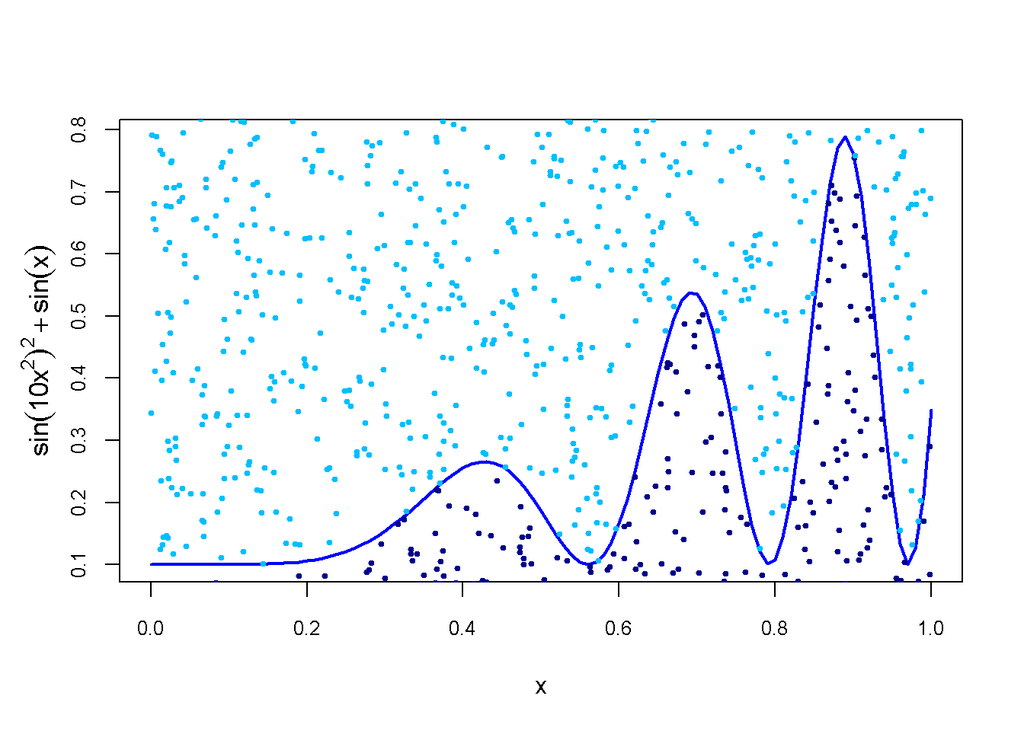

```r
  # Geração dos pontos
N <- 1E3
x1 <- runif(N, min = 0 , max =1 )
y1 <- runif(N, min = 0 , max =1 )

  # aceitação/rejeição dos pontos
aceita <- f(x1) > y1
  # aceita = T; rejeita = F
codigos <- as.factor(aceita)


  # cores dos pontos conforme região
cores <- c("deepskyblue", "darkblue")

  # gráfico da função
curve(f, from = 0, to = 1, lwd = 2, col = "blue", ylab = "", cex.axis = 0.8)
title(ylab = expression(sin(10*x^2)^2+sin(x)), line = 2, cex.lab = 1.1)

  # anotação dos pontos gerados
points(x1, y1, col = cores[codigos], pch = 20, cex = 0.75)
```

```r
  # aproximação área abaixo da curva
(int.est <- sum(aceita)/N)
```

```
## [1] 0.265
```

```r
  # erro relativo da estimativa
(int.err <- (int.est - int.ex)/int.ex)
```

```
## [1] 0.09218561
```

```r
est.1e3 <- c(int.est, int.err)
```

A estimativa obtida foi 0.265, com um erro relativo de 0.0921856. Vamos verificar a estimativa com $N=10000$.

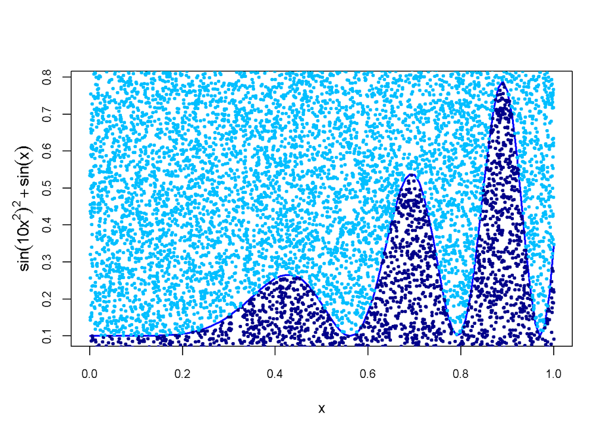

```r
        # --------  10000 pontos


  # Geração dos pontos
N <- 1E4
x1 <- runif(N, min = 0 , max =1 )
y1 <- runif(N, min = 0 , max =1 )

  # aceitação/rejeição dos pontos
aceita <- f(x1) > y1
  # aceita = T; rejeita = F
codigos <- as.factor(aceita)


  # cores dos pontos conforme região
cores <- c("deepskyblue", "darkblue")

  # gráfico da função
curve(f, from = 0, to = 1, lwd = 2, col = "blue", ylab = "", cex.axis = 0.8)
title(ylab = expression(sin(10*x^2)^2+sin(x)), line = 2, cex.lab = 1.1)

  # anotação dos pontos gerados
points(x1, y1, col = cores[codigos], pch = 20, cex = 0.75)
```

```r
  # aproximação área abaixo da curva
(int.est <- sum(aceita)/N)
```

```
## [1] 0.2466
```

```r
  # erro relativo da estimativa
(int.err <- (int.est - int.ex)/int.ex)
```

```
## [1] 0.01635083
```

```r
est.10e3 <- c(int.est, int.err)
```

A estimativa obtida foi 0.2466, com um erro relativo de 0.0163508. Vamos verificar a estimativa com $N=15000$.

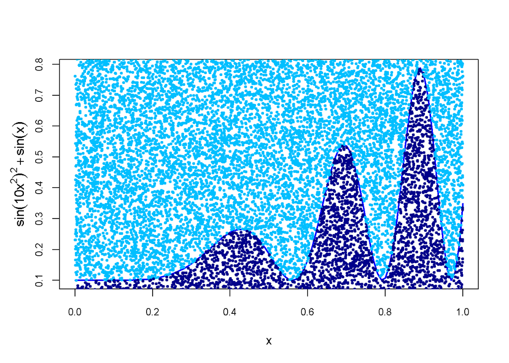

```r
        # --------  15000 pontos


  # Geração dos pontos
N <- 1.5E4
x1 <- runif(N, min = 0 , max =1 )
y1 <- runif(N, min = 0 , max =1 )

  # aceitação/rejeição dos pontos
aceita <- f(x1) > y1
  # aceita = T; rejeita = F
codigos <- as.factor(aceita)


  # cores dos pontos conforme região
cores <- c("deepskyblue", "darkblue")

  # gráfico da função
curve(f, from = 0, to = 1, lwd = 2, col = "blue", ylab = "", cex.axis = 0.8)
title(ylab = expression(sin(10*x^2)^2+sin(x)), line = 2, cex.lab = 1.1)

  # anotação dos pontos gerados
points(x1, y1, col = cores[codigos], pch = 20, cex = 0.75)
```

```r
  # aproximação área abaixo da curva
(int.est <- sum(aceita)/N)
```

```
## [1] 0.2377333
```

```r
  # erro relativo da estimativa
(int.err <- (int.est - int.ex)/int.ex)
```

```
## [1] -0.02019274
```

```r
est.15e3 <- c(int.est, int.err)
```

As estimativas apresentaram os seguintes erros relativos ao estimar a quantidade exata (0.2426328). São significativas as modificações no erro relativo à medida que o tamanho de pontos gerados aumenta.

```
##       estimativa Erro relativo
## 1000   0.2650000    0.09218561
## 10000  0.2466000    0.01635083
## 15000  0.2377333   -0.02019274
```

Temos entretanto algumas questões com relação à esta abordagem: o esforço computacional e a precisão, já que apenas uma parte dos pontos gerados foi utilizado na estimação. Além disso, surge uma pergunta: como estimar integrais impróprias?

### Integração Monte Carlo para integrais definidas no intervalo $(0,1)$:

Há um outro tipo de abordagem que leva a resultados mais precisos, com um menr esforço computacional. Seja uma função $g(x)$ e suponha que desejamos calcular $\theta$, em que:
$$\theta = \int_0^1g(x) \,\operatorname{d}\! x %\mathrm{d}x.$$

Perceba que, se $U \sim \mathcal{U}(0,1)$, podemos expressar o valor de $\theta$ como:

$$\theta = \operatorname{E}[g(U)].$$

Se $U_1, U_2, \dots, U_n$ são variáveis aleatórias independentes e uniformente distribuídas sobre o intervalo $(0, 1)$, então, $g(U_1), g(U_2), \dots, g(U_n)$ são variáveis aleatórias independentes e identicamente distribuídas, com média $\theta$. Portanto, pela *Lei Forte dos Grandes Números*, segue que, com probabilidade 1:
$$\bar{\theta}_n = \frac{1}{n}\sum_{i=1}^n g(U_i) \to \operatorname{E}[g(U)]=\theta, \, \text{para } n \to \infty.$$

Ou seja, podemos obter uma aproximação de $\theta$ gerando um *grande* número de números aleatórios $u_i$ e usar a média dos valores $g(u_i)$ como uma aproximação de $\theta$. Essa abordagem para estimação de integrais definidas é denominada *Integração Monte Carlo*.

#### Exemplo

Estimar a integral definida:
$$B(x, y) = \int_0^1 (1-t)^{y-1} t^{x-1} \, \operatorname{d}\! t, \, x>0, \, y>0$$

### Integração Monte Carlo para integrais definidas com suporte compacto:

Integrais do tipo:

$$\theta = \int_a^b g(x) \operatorname{d}\! x.$$

Para se usar o mesmo procedimento (aproximação pela média dos valores da função $g$ avaliada em valores aletaórios de uma uniforme), pode-se usar uma substituição conveniente para transfomar os limites de integração do intervalo $(a, b)$ para o intervalo $(0, 1)$. Se substituímos a variável $x$ por:
$$u = \frac{(x-a)}{b-a},$$

então, $\operatorname{d}\! u = \frac{\operatorname{d}\! x}{(b-a)}$ e os extremos de integração tornam-se $0$ e $1$. Logo:
$$\theta = \int_0^1 g(a + [b-a]y)\, (b-a) \, \operatorname{d}\! y,$$

ou, de maneira mais simplificada

$$\begin{equation}
\theta = \int_a^b g(x) \operatorname{d}\! x = \int_0^1 h(u) \, \operatorname{d}\! u,
\end{equation}$$

com $h(u) = (b - a)g(a + [b-a]u)$, com $0 < u < 1$.

Dessa maneira $\theta$ pode ser aproximada pela geração de números aleatórios uniformente distribuídos no intervalo $(0, 1)$, estimando-se $\theta$ pelo valor médio da função $h$, calculadas nesses números aleatórios.

#### Exemplo

Usar integração Monte Carlo para estimar a probabilidade $\operatorname{P}(1 < Z < 2)$, sendo $Z$ a variável aleatória normal padrão. Deseja-se então estimar a quantidade:

$$\theta = \operatorname{P}(1 < Z < 2) =
\int_1^2 \frac{1}{\sqrt(2\pi)} \operatorname{e}^{-\frac{z^2}{2}}
\, \operatorname{d}\! z.$$

A transformação adequada é para a função $h(u) = (2 - 1)g(1 + [2-1]u$, ou seja:

$$\theta = \int_0^1 \frac{1}{\sqrt(2\pi)} \operatorname{e}^{-\frac{(u + 1)^2}{2}}
\, \operatorname{d}\! u.$$

### Integração Monte Carlo para integrais definidas com suporte na semi-reta:

Integrais do tipo:

$$\theta = \int_0^\infty g(x) \operatorname{d}\! x.$$

Uma substituição conveniente para transfomar os limites de integração do intervalo $(0, \infty)$ para o intervalo $(0, 1)$ é substituímos a variável $x$ por:
$$u = \frac{1}{x + 1},$$

então, $\operatorname{d}\! u = \frac{-\operatorname{d}\! x}{(x+1)^2}$ e os extremos de integração tornam-se $0$ e $1$. Logo:
$$\theta = \int_0^1 \frac{g(\frac{1}{u}-1)}{u^2}\, \operatorname{d}\! u,$$

ou seja,
$$\theta = \int_0^\infty g(x) \operatorname{d}\! x = \int_0^1 h(u) \, \operatorname{d}\! u,$$
em que $h(u) = \frac{g\left(\frac{1}{u}-1\right)}{u^2}$, com $0 < u < 1$.

#### Exemplo

Usar integração Monte Carlo para estimar a quantidade:
$$\theta = \int_0^\infty \operatorname{e}^{-x^2} \,\operatorname{d}\! x$$

Uma transformação conveniente é a função $h(u) = \frac{\operatorname{e^{-\left(\frac{1}{u}-1 \right)^2}}}{u^2}$, ou seja:

$$\theta = \int_0^1 \frac{\operatorname{e^{-\left(\frac{1}{u}-1 \right)^2}}}{u^2}
\, \operatorname{d}\! u.$$

Há outras parametrizações possíveis, como por exemplo $u = \frac{x}{1 + x}$, em que $\operatorname{d}\! u = \frac{\operatorname{d}\! x}{(1 - x)^2}$. Dessa maneira:
$$\theta = \int_0^\infty f(x) \, \operatorname{d}\! x =
\int_0^1 \frac{f\left(\frac{u}{1 - u} \right)}{(1 - u)^2} \, \operatorname{d}\! u$$

A quantidade $\theta$ pode também ser expressa como:
$$\theta = \int_0^\infty f(x) \operatorname{d}\! x = \int_0^1 f(x) \operatorname{d}\! x +
\int_1^\infty f(x) \operatorname{d}\! x$$

e, dessa maneira, a substituição $u = \frac{1}{x}$, com $\operatorname{d}\! u = - \frac{\operatorname{d}\! x}{x^2}$ permite obtermos duas integrais definidas no intervalo $(0, 1)$.

### Integral Clássica de Monte Carlo:

Denominamos o procedimento em estudo como Método Clássico de Integração de Monte Carlo. Seja o problema genérico de avaliar a integral

$$\tag{*}
\operatorname{E}_f[h(X)] = \int_{R_X} h(x) f(x) \, \operatorname{d}\! x,$$

em que, $f(x)$ é a função de densidade de probabilidade da variável aleatória $X$ e $h$ uma função.

Seja, por exemplo, $\operatorname{E}(X) = \mu$ e $h(x) = (x - \mu)^2$, então $\operatorname{E}[h(X)]= \operatorname{E}(X-\mu)^2 = \operatorname{Var}(X)$. Uma outra situação é para $h(x) = \mathbb{I}_A(x)$, em que:

$$\mathbb{I}_A(x) = \begin{cases}
1 &, \text{ se } x \in A \\
0 &, \text{ se } x \not\in A,
\end{cases}$$

logo, $\operatorname{E}[h(X)] = \operatorname{P}(A)$.

Nesse contexto, para estimar $\operatorname{E}[h(x)]$ $(*)$ , é natural propor o uso de uma sequência de números aleatórios $(X_1, X_2, \dots, X_n)$, uma amostra da variável aleatória $X$, com função de densidade de probabilidade $f$, para aproximar pela média empírica:

$$\bar{h}_n = \frac{1}{n}\sum_{j=1}^n h(x_j)$$

Pela Lei Forte dos Grandes Números, a média amostral $\bar{h}_n$ converge quase certamente para $\operatorname{E}_f[h(x)]$. Quando $h^2$ tem esperança finita sob $f$, a velocidade de convergência de $\bar{h}_n$ pode ser calculada, já que:

$$\operatorname{Var}(\bar{h}_n) = \frac{\operatorname{Var}[h(X)]}{n} = \frac{1}{n} \int_{R_X}
(h(x) - \operatorname{E}_f[h(x)])^2 f(x) \operatorname{d}\! x,$$

e pode ser estimada pela amostra $(X_1, X_2, \dots, X_n)$ por meio da estatística:

$$v_n = \frac{1}{n} \sum_{j=1}^n
(h(x_j) - \bar{h}_n)^2,$$

já que
$$\hat{\operatorname{Var}[h(X)]} = \frac{\sum_{j=1}^n(h(x_j) - \bar{h}_n)^2}{m-1} \approx \frac{\sum_{j=1}^n(h(x_j) - \bar{h}_n)^2}{m}.$$

Assim, o erro padrão associado aos erros padrão da estimativa Monte Carlo são:

$$\operatorname{ep}_{\bar{h}} = \sqrt{\operatorname{Var}(\bar{h}_n)}
\approx \sqrt{\frac{\hat{\operatorname{Var}[h(X)]}}{m}}.$$

Por outro lado, para $n$ suficientemente grande

$$\frac{\bar{h}_n - \operatorname{E}_f[h(X)]}{\sqrt{v_n}} \sim \mathcal{N}(0,1).$$

Esse fato permite a construção de teste de convergência e de limites de confiança para a aproximação de $\operatorname{E}_f[h(X)]$.

#### Exemplo

A função de distribuição acumulada de uma normal não pode ser expressa de forma explícita. É possível utilizarmos simulações na construção de tabelas com probabilidades acumuladas dessa distribuição.

Considere uma amostra aleatória de tamanho `n`, $(x_1, x_2, \dots, x_n)$, gerada pelo algoritmo de Box-Muller. A o valor da função de probabilidade acumulada em $t$:

$$\Phi(t) = \int_{-\infty}^t \frac{1}{\sqrt{2 \pi}}\operatorname{e}^{- \frac{z^2}{2}} \operatorname{d}\! z,$$

pode ser aproximada pelo método de Monte Carlo por meio de:
$$\hat{\Phi}(t) = \frac{1}{n}\sum_{j=1}^n \mathbb{I}_{x_j \leq t}.$$

A variância exata de $\hat{\Phi}(t)$ é:

$$\frac{\Phi(t)(1- \Phi(t))}{n},$$

já que as variáveis aleatórias $\mathbb{I_{x_j \leq t}}$ são independentes e identicamente distribuídas de acordo a uma distribuição de Bernoulli, com probabilidade de sucesso $\Phi(t)$.

Percebe-se que, para valores de $t$ em torno de zero, a variância é aproximadamente $\frac{1}{4n}$. Assim, para obter-se uma precisão de 4 casa decimais, a aproximação de Monte Carlo exige uma média $n=(\sqrt{2}\, 10^4)^2$ iterações, ou seja, aproximadamente 200 milhões de iterações.

Robert e Casella (1999) avaliaram a estimação por integração de Monte Carlo de probabilidades de uma normal padrão para vários valores de `t`, apresentando os resultado da tabela abaixo:

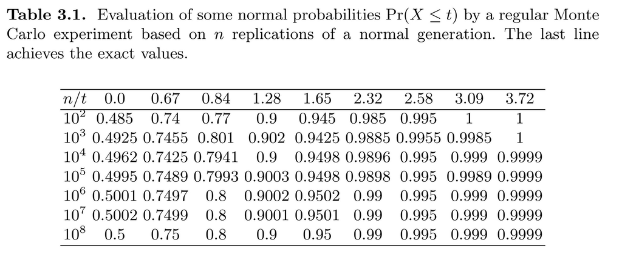

A avaliação é precisa (considerada exata) para 100 milhões de iterações, percebendo-se maior precisão nas caudas. Há métodos mais eficientes para serem usados na estimação dos valores dessas probabilidade, como, por exemplo a *importance sampling*.

#### Exemplo - *Toy function*

Seja a função:

$$h(x) = [cos(50x) + sin(20x)]^2,$$

cujo gráfico encontra-se no painel superior da figura abaixo. Embora essa função possa ser integrada analiticamente, pode-se usar o método Monte carlo para estimadar a quantidade $\int_0^1h(x) \operatorname{d}\! x$. Essa integral pode ser vista como $\operatorname{E}_U[h(x)]$, como $U \sim \mathcal{U}(0,1)$. Dessa maneira, podemos obter uma aproximação do valor da integral por meio da média amostral $\sum_{j=1}^n h(U_i)$, em que $U_1, U_2, \dots, U_n$ é uma sequência de números aleatórios independentes e identicamente distribuídas, gerados ao acaso no intervalo $(0, 1)$.

```r
            #  ------------------------------------------
            #       Integração da Toy Function
            #  ------------------------------------------


  # função h(x)
h <- function(x){(cos(50*x)+sin(20*x))^2}

  # parâmetros do gráfico
par(mar = c(2, 2, 2, 1), mfrow = c(2, 1))

  # Gráfico da função
curve(h, xlab = "Função", ylab = "", lwd = 2)

  # valor exato da integral
(int.ex <- integrate(h, 0, 1)$value)
```

```
## [1] 0.9652009
```

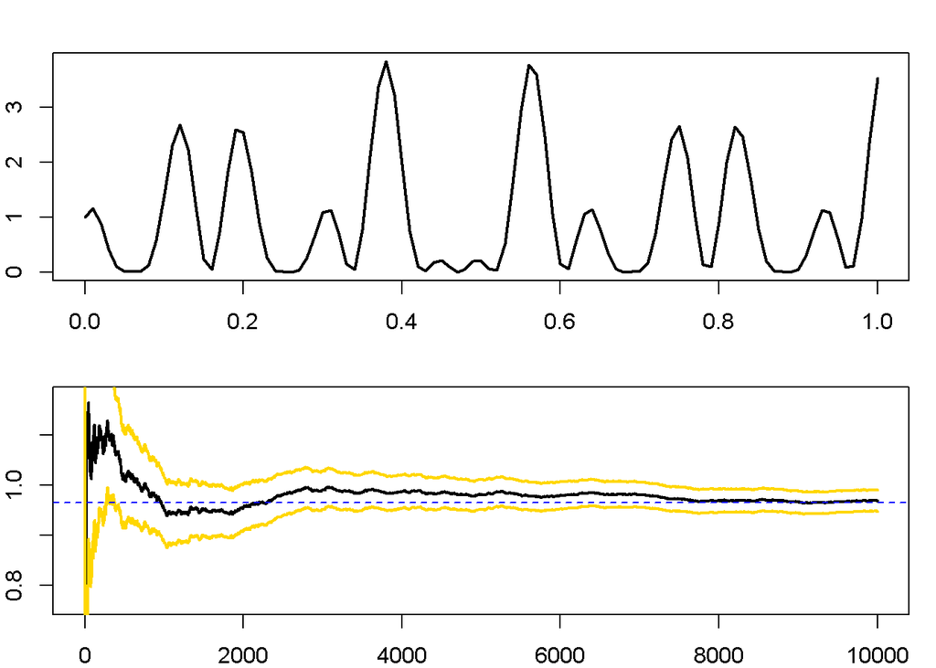

```r
        # -----  Aproximação Monte Carlos

n <- 1E4
U <- runif(n)
x <- h(U)

  # estimativa móvel da integral
int.est <- cumsum(x)/(1:n)

  # erro padrão móvel da estimativa
err.est <- sqrt(cumsum((x - int.est)^2))/(1:n)

  # gráfico da estimativa móvel da integral
plot(int.est, xlab = "Média e intervalo de erro", type = "l", lwd= 2,
    ylim = mean(x) + 20*c(-err.est[n], err.est[n]), ylab="")

  # limites do intervalo de errro
lines(int.est + 2*err.est, col = "gold", lwd = 2)
lines(int.est - 2*err.est, col = "gold", lwd = 2)

  # objetivo - valor exato da integral
abline(h = int.ex, lty = 2, col = "blue")
```

O painel inferior apresenta a média móvel e os limites obtidos a partir dos erros padrão estimados versus a quantidade de simulações (`n`). A banda de confiança obtida não é a clássica banda com 95% de confiança.

### Estimação Monte Carlo de Integrais Múltiplas

A utilidade de usar números aleatórios para aproximar integrais se torna mais aparente no caso de integrais multidimensionais. Seja $g$ uma função em $\mathbb{R}^p$ e estamos interessados em calcular:

$$\theta = \int_0^1\int_0^1 \dots \int_0^1 g(x_1, x_2, \dots, x_p) \operatorname{d}\! x_1 \operatorname{d}\! x_2 \dots \operatorname{d}\! x_p.$$

pode ser expresso como a seguinte esperança:

$$\operatorname{E}[g(U_1, U_2, \dots, U_p)],$$

em que $U_1, U_2, \dots, U_p$ são variáveis aleatórias independentes e uniformemente distribuídas no intervalo $(0,1)$.

Seja a geração de $n$ conjuntos independentes, com $p$ variáveis aleatórias uniformes independentes:

$$\begin{align}
(U_1^{(1)}, U_2^{(1)}, & \dots, U_p^{(1)}) \\
(U_1^{(2)}, U_2^{(2)}, & \dots, U_p^{(2)}) \\
& \vdots \\
(U_1^{(n)}, U_2^{(n)}, & \dots, U_p^{(n)}) .
\end{align}$$

Por outro lado, as variáveis aleatórias $g(U_1^{(j)}, U_2^{(j)}, \dots, U_p^{(j)})$, $j=1, 2, \dots, p$, são variáveis aleatórias independentes e identicamente distribuídas, com média $\theta$. Então podemos estimar $\theta$ por:

$$\bar{\theta} = \frac{\sum_{j=1}^n g(U_1^{(j)}, U_2^{(j)}, \dots, U_p^{(j)})}{n}.$$

#### Exemplo

Duas pessoas têm encontro no Poleiro do Galo no Valentine’s Day. `P2` chega ao acaso entre 22:00 e 23:30 e `P1`, entre 22:30 e 24:00.

Sejam $T_1$ e $T_2$ as avriáveis aleatórias associadas ao tempo de chegada (medidos em horas após o meio-dia) de `P1` e `P2`, respectivamente. Assume-se que $T_1$ e $T_2$ são independentes, com $T_1$, distribuída uniformemente no intervalo $(10.5, 12.0)$ e $T_2$, no intervalo $(10.0, 11.5)$. Deseja-se obter a probabilidade:

$$\operatorname{P}\{T_1 < T_2\} = \int_{t_1 < t_2}
f_{T_1}(t_1) f_{T_2}(t_2) \operatorname{d}\! t_1 \operatorname{d}\! t_2,$$

em que $f_{T_1}$ e $f_{T_2}$ denotam as funções de densidade de probabilidade uniformes para $T_1$ e $T_2$, respectivamente. Dada a suposição de independência, a função de densidade de probabilidade conjunta de $(T_1, T_2)$ é $f_{T_1, T_2}(t_1 t_2) = f_{T_1}(t_1)f_{T_2}(t_2)$. A probabilidade de interesse pode ser representada pela esperança:

$$\operatorname{P}\{T_1 < T_2\} = \operatorname{E}(\mathbb{I}(T_1<T_2)) =
\int \mathbb{I}(T_1<T_2)
f_{T_1}(t_1) f_{T_2}(t_2) \operatorname{d}\! t_1 \operatorname{d}\! t_2,$$

em que $\mathbb{I}(T_1<T_2)$ é a função indicadora de $T_1<T_2$, ou seja, é iguala a um quando $t_1 < t_2$ e zero, caso contrário. Para aproximar essa integral pelo método de Monte Carlo, simula-se uma grande número, digamos 1000, de valores da distribuição de $(T_1, T_2)$. Como $T_1$ e $T_2$ são independentes, simulamos 1000 valores de $T_1$, da distribuição uniforme no intervalo $(10.5, 12)$ e, independentemente, outros 1000 valores da distribuição uniforme no intervalo $(10, 11.5)$.

```r
  # geração dos tempos de chegada
n <- 1E3
t1 <- runif(n, 10.5, 12)
t2 <- runif(n, 10, 11.5)

  # estimativa da probabilidade
prob <- sum(t1 < t2)/n
prob
```

```
## [1] 0.225
```

A estimativa da probabilidade $\operatorname{P}(T_1 < T_2)$ é dada pela proporção dos pares ordenados simulados $(t_1, t_2)$, nos quais $t_1 < t_2$. Estima-se que a probabilidade de `P1` chegar antes de `P2` é 0.225.

[figure not shown]

```r
  # Figura da simulação
cores <- c("deepskyblue", "darkblue")
aceita <- as.factor(t1 < t2)
plot(t2, t1, xlab = "P2", ylab = "P1", type = "n")

  # área de integração
polygon(c(10.5, 11.5, 11.5, 10.5), c(10.5, 10.5, 11.5, 10.5), density = 10,
    angle = 135)
  # área descartada
polygon(c(10, 10.5, 11.5, 11.5, 10), c(10.5, 10.5, 11.5, 12, 12), col = "cyan")

  # pontos simulados
points(t2, t1, pch = 19, col=cores[aceita])
```

A figura ilusta o processo de estimação da probabilidade. A região hachurada representa a região em que $(T_1 < T_2)$ e a estimativa Monte Caro é a proporção de pontos simulados que pertence à área hachurada. A função `polygon()` adiciona a área hachurada (região de aceitação) e a área colorida (região de rejeição).

Como essa estimativa Monte Carlo da probabilidade é uma proporção, podemos usar a fórmula usual do erro padrão de uma proporção para calcular o erro padrão dessa estimativa:

$$\operatorname{ep}_\hat{p} = \sqrt(\frac{\hat{p}(1-\hat{p})}{n}),$$

em que $n$ é a quantidade de pares ordenados simulados. Para nossa estimativa, obtemos:

```r
  # erro padrão
(ep <- sqrt(prob * (1 - prob)/n))
```

```
## [1] 0.01320511
```

2. Qual a diferença esperada entre os dois tempos de chegada

Como é mais provável que `P1` chegue mais tarde que `P2`, desejamos calcular a esperança $\operatorname{E}(T_1 - T_2)$, que pode ser calculada por:

$$\operatorname{E}(T_1 - T_2) = \int(t_1 - t_2) f_{T_1}(t_1) f_{T_2}(t_2) \operatorname{d}\! t_1 \operatorname{d}\! t_2$$

A estimativa Monte Carlo dessa esperança é dada por:

$$\widehat{\operatorname{E}(T_1 - T_2)} =
\frac{\sum_{j=1}^n(T_1^{(j)} - T_2^{(j)})}{n},$$

em que $(T_1^{(j)}, T_2^{(j)}) é um ponto simulado da densidade conjunta de $(T_1, T_2)$, ou seja, a estimativa Monte Carlo da diferença é dada por:

```r
  # diferença de chegadas em cada encontro
diferenca <- t1 - t2

  # estimativa Monte Carlo da esperança
(E.mc <- mean(diferenca))
```

```
## [1] 0.4861744
```

```r
  # Erro padrão da estimativa Monte Carlo da esperança
(ep.mc <- sd(diferenca)/sqrt(n))
```

```
## [1] 0.01919389
```

Estimamos que `P1` vai chegar, em média, 0.49 horas mais tarde que `P2`. Como o erro padrão é 0.02, estamos 95% confiantes que a verdadeira diferença está num intervalo de 0.04 dessa estimativa. Ressalta-se que o valor exato dessa diferença é `0.5`.

#### Exemplo - Estimação de $\pi$

Suponha que o vetor aleatório $(X,Y)$ esteja uniformemente distribuído em um quadrado de área 4, centrado na origem. Considere agora a probabilidade de um ponto aleatório $(X,Y)$ estar contido em um círculo de raio 1, inscrito nesse quadrado.

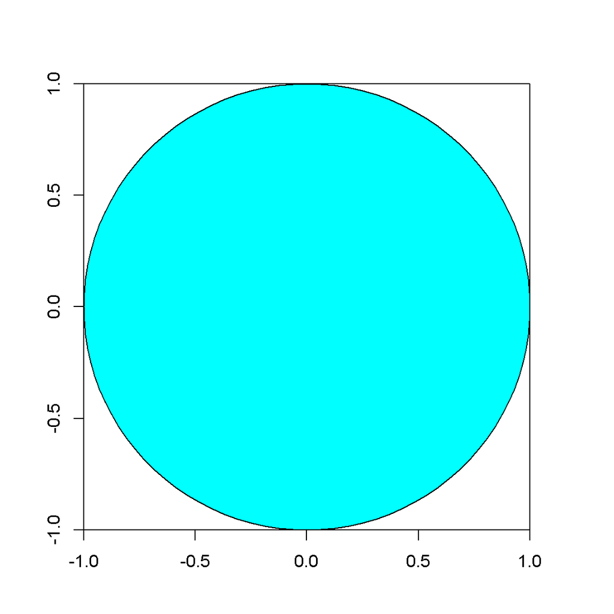

```r
par(mar = c(4.1, 4.1, 4.1, 4.1))
plot(NA, xlim = c(-1, 1), ylim = c(-1, 1), type = "n", xaxs="i",yaxs="i",
    ylab = "", xlab = "")
  # círculo
plotrix::draw.circle(0, 0, 1, col = "cyan")
```

Como o vetor aleatório $(X,Y)$ está uniformemente distribuído no quadrado, tem-se que:

$$\operatorname{P}\{(X, Y) \in \text{ círculo} \} =
\operatorname{P}\{X^2 + Y^2 \leq 1 \} = \frac{\text{área círculo}}{\text{área quadrado}} = \frac{\pi}{4}$$

Portanto, se gerarmos um grande número de pontos aleatórios no quadrado, a proporção de pontos que pertencerá ao círculo será aproximadamente $\pi/4$. Assim, se $X$ e $Y$ forem independentes e uniformemente distribuídas entre $(-1, 1)$, sua função de densidade de probabilidade conjunta será:

$$\begin{align}
f_{XY}(x,y) & =f_X(x) f_Y(y) \\
& = \frac{1}{2}\cdot \frac{1}{2} \\
& = \frac{1}{4} \text{, }-1 \leq x \leq 1
\text{, }-1 \leq y \leq 1.
\end{align}$$

Como a densidade de $(X, Y)$ é constante no quadrado, por definição, $(X,Y)$ é uniformemente distribuída no quadrado. Por outro lado, se $U$ é uniformemente distribuída no intervalo $(0, 1)$, então $2U$ é uniforme em $(0, 2)$ e $(2U -1)$ é uniforme em $(-1,1)$. Então, podemos implementar o seguinte algoritmo para efetuar essa estimativa:

```
1. Gerar ao acaso os números U1 e U2
2. Calcular X = 2U1 -1 e Y = 2U2 - 1
3. Calcular a proporção de pares em que X^2 + Y^2 <= 1.
```

Perceba que se
$$\mathbb{I}(x, y) = \begin{cases}
1 & \text{, se } X^2 + Y^2 \leq 1 \\
0 & \text{, caso contrário,}
\end{cases}$$

então

$$\begin{align}
\operatorname{E}[\mathbb{I}(x,y)] & =
\int_\Omega \mathbb{I}(x,y) \operatorname{d}\! x \operatorname{d}\! y \\
& = \operatorname{P}\{ X^2 + Y^2 \leq 1 \} \\
& = \frac{\pi}{4},
\end{align}$$

em que $\Omega = [-1, 1] \times [-1, 1]$

O seguinte código seria uma possível implementação para esse algoritmo de simulação Monte Carlo:

```r
    # Estimação de pi

  # geração da uniforme (0,1)
n <- 1E3
u1 <- runif(n)
u2 <- runif(n)

  # geração dos pares ordenados
x <- 2*u1 - 1
y <- 2*u2 - 1

circulo <- x^2 + y^2 <= 1

  # Proporção de pontos no círculo
(mean(circulo))
```

```
## [1] 0.779
```

```r
  # Estimativa de pi
mean(circulo)*4
```

```
## [1] 3.116
```

Essa estimativa apresenta os seguintes erro amostral e erro relativo:

```r
    # erro amostral
mean(circulo)*4 - pi
```

```
## [1] -0.02559265
```

```r
  # erro amostral
(mean(circulo)*4 - pi)/pi
```

```
## [1] -0.008146395
```

A simulação apresentou o seguinte comportamento, sendo que 77.9% dos pontos situaram-se dentro do cícrulo.

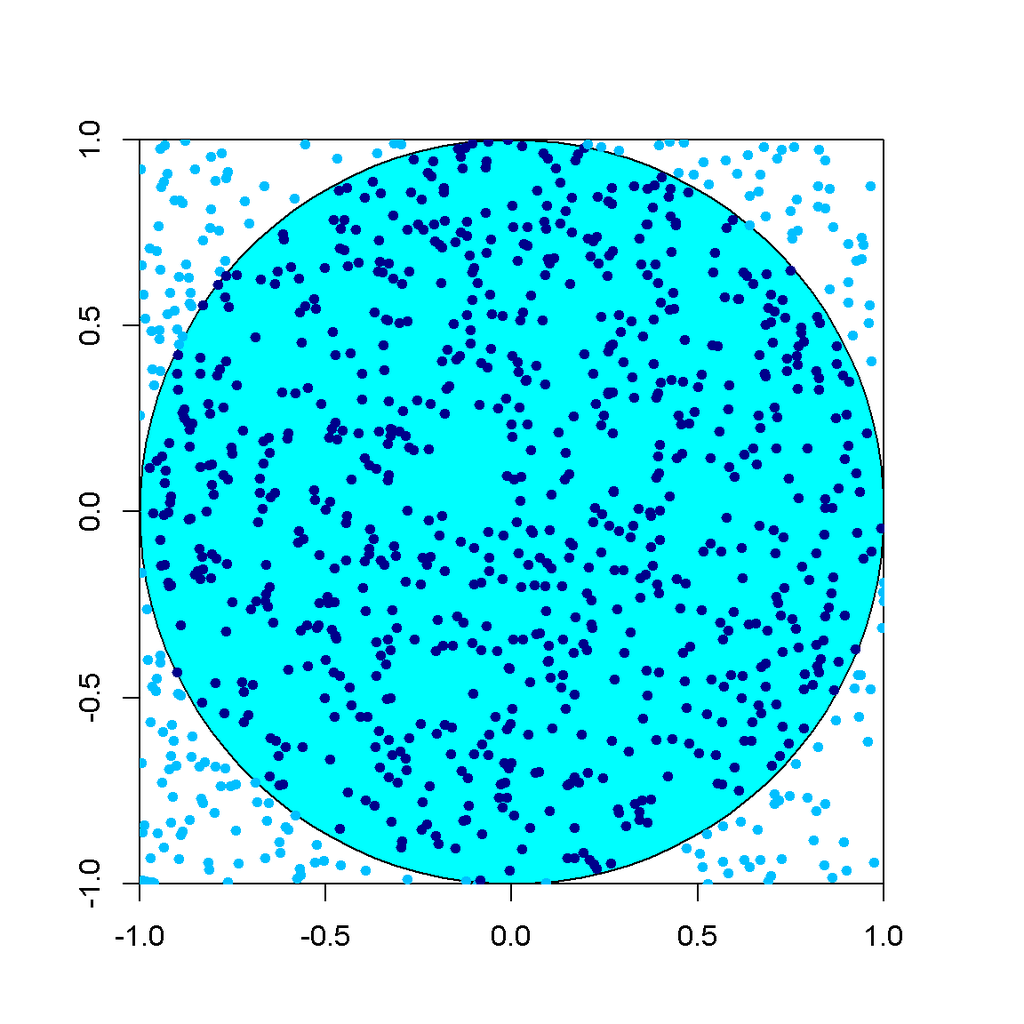

```r
    # Pontos plotados
par(mar = c(4.1, 4.1, 4.1, 4.1))

cores <- c("deepskyblue", "darkblue")
aceita <- as.factor(circulo)
plot(NA, xlim = c(-1, 1), ylim = c(-1, 1), type = "n", xaxs = "i", yaxs = "i",
    ylab = "", xlab = "")
  # círculo
plotrix::draw.circle(0, 0, 1, col = "cyan")
  # pontos gerados
points(x, y, pch = 19, col=cores[aceita], cex = 0.75)
```